# Scenario: Haulout Reduction @ Nisqually

Describing the model run when the number of pinnipeds in the source pool is reduced at Nisqually

October 22, 2024

### The Narrative

This model run is a scenario where managers or harvesters (or both) implement removals or intensive disturbance at nearby haulouts (the “source pool”) which reduces the number of pinnipeds which can access the Gauntlet daily. This scenario would also likely have multi-year population-level effects which we are not describing here.

### Run the Model

Parameters listed below are altered from the base run parameterization to simulate the management scenario. For this scenario we’re altering the number of pinnipeds in the source pool.

```r
# source pool reduction factor:
reduction <- 0.5

# adjust parameters for management scenario
num_seals <- num_seals * reduction
num_ej <- num_ej * reduction
num_zc <- num_zc * reduction
```

### Description of Parameterization

This parameterization focuses on a scenario where the source pool of pinnipeds (of all three species) has been reduced by 50% through some action external to the Gauntlet itself - harvest, lethal removals by management, or abandonment caused by intense disturbance. Under this scenario, pinniped presence at the Gauntlet is reduced as seen below.

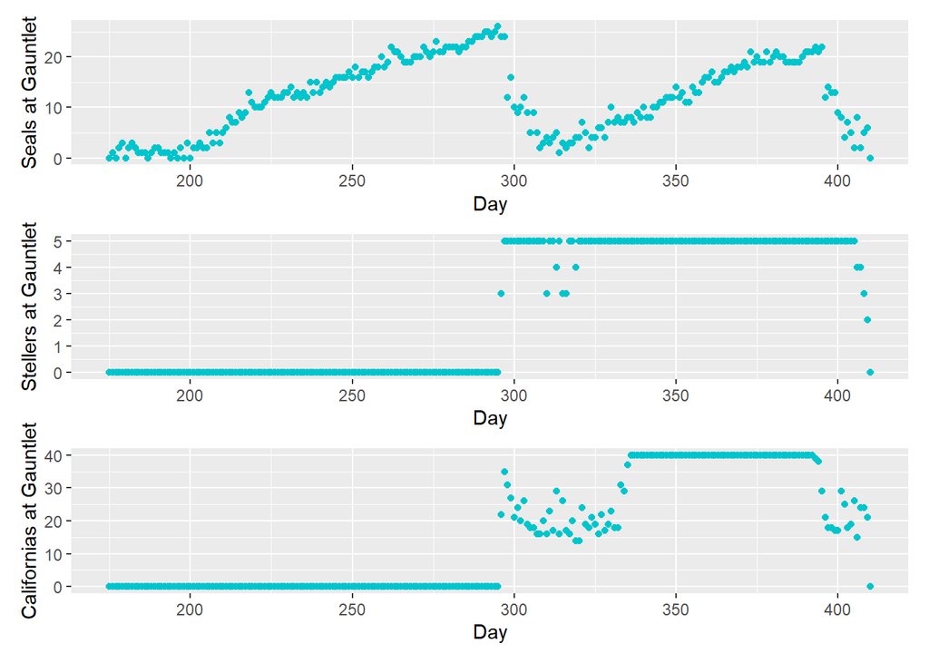

Under this scenario, there are still baseline levels of incidental take, which in the Nisqually system is very low or non-existent.

Harvested Pinnipeds

| Pv | Ej | Zc |
| --- | --- | --- |
| 0 | 0 | 0 |

Because pinniped presence at the Gauntlet is lower than the base run under this parameterization, salmon consumption is lower and salmon escape is higher.

|  | Chum | Chinook_GR | Chinook_LN |
| --- | --- | --- | --- |
| Escape | 7283 | 11277 | 493 |
| Catch | 6156 | 4922 | 83 |
| Predated | 12267 | 3618 | 225 |

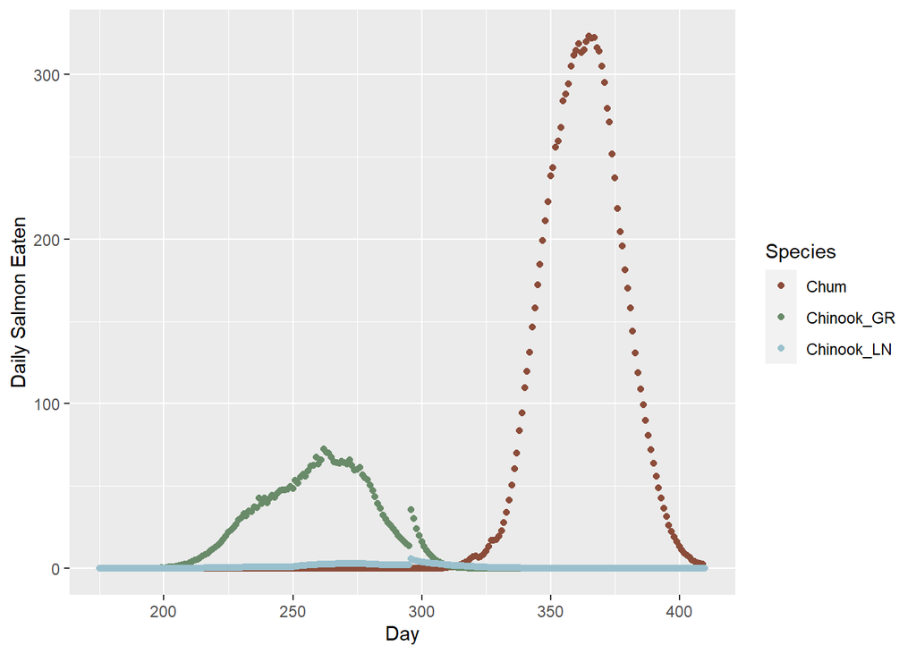

### Parameter Table

|  | Value |
| --- | --- |
| num_seals | 75.0 |
| num_zc | 40.0 |
| num_ej | 5.0 |
| chum_residence | 21.0 |
| gr_residence | 14.0 |
| locnis_residence | 7.0 |
| chin_boats | 14.0 |
| min_chum_boats | 1.0 |
| max_chum_boats | 25.0 |
| reduction | 0.5 |